# Risk Factor Analysis

## Outcome Variable

**Outcome Variable:** stunted

## Predictor Variables

**Intervention Variable:** mage

**Adjustment Set:**

unadjusted

## Stratifying Variables

The analysis was stratified on these variable(s):

- agecat
- studyid
- country

## Data Summary

| agecat | studyid | country | mage | stunted | n_cell | n |
| --- | --- | --- | --- | --- | --- | --- |
| Birth | CMC-V-BCS-2002 | INDIA | [20-30) | 0 | 65 | 92 |
| Birth | CMC-V-BCS-2002 | INDIA | [20-30) | 1 | 14 | 92 |
| Birth | CMC-V-BCS-2002 | INDIA | <20 | 0 | 7 | 92 |
| Birth | CMC-V-BCS-2002 | INDIA | <20 | 1 | 2 | 92 |
| Birth | CMC-V-BCS-2002 | INDIA | >=30 | 0 | 3 | 92 |
| Birth | CMC-V-BCS-2002 | INDIA | >=30 | 1 | 1 | 92 |
| Birth | COHORTS | GUATEMALA | [20-30) | 0 | 386 | 852 |
| Birth | COHORTS | GUATEMALA | [20-30) | 1 | 19 | 852 |
| Birth | COHORTS | GUATEMALA | <20 | 0 | 112 | 852 |
| Birth | COHORTS | GUATEMALA | <20 | 1 | 9 | 852 |
| Birth | COHORTS | GUATEMALA | >=30 | 0 | 304 | 852 |
| Birth | COHORTS | GUATEMALA | >=30 | 1 | 22 | 852 |
| Birth | COHORTS | INDIA | [20-30) | 0 | 2795 | 4715 |
| Birth | COHORTS | INDIA | [20-30) | 1 | 385 | 4715 |
| Birth | COHORTS | INDIA | <20 | 0 | 309 | 4715 |
| Birth | COHORTS | INDIA | <20 | 1 | 59 | 4715 |
| Birth | COHORTS | INDIA | >=30 | 0 | 1053 | 4715 |
| Birth | COHORTS | INDIA | >=30 | 1 | 114 | 4715 |
| Birth | COHORTS | PHILIPPINES | [20-30) | 0 | 1725 | 3050 |
| Birth | COHORTS | PHILIPPINES | [20-30) | 1 | 96 | 3050 |
| Birth | COHORTS | PHILIPPINES | <20 | 0 | 342 | 3050 |
| Birth | COHORTS | PHILIPPINES | <20 | 1 | 36 | 3050 |
| Birth | COHORTS | PHILIPPINES | >=30 | 0 | 796 | 3050 |
| Birth | COHORTS | PHILIPPINES | >=30 | 1 | 55 | 3050 |
| Birth | EE | PAKISTAN | [20-30) | 0 | 61 | 239 |
| Birth | EE | PAKISTAN | [20-30) | 1 | 33 | 239 |
| Birth | EE | PAKISTAN | <20 | 0 | 0 | 239 |
| Birth | EE | PAKISTAN | <20 | 1 | 1 | 239 |
| Birth | EE | PAKISTAN | >=30 | 0 | 79 | 239 |
| Birth | EE | PAKISTAN | >=30 | 1 | 65 | 239 |

[output cut: 378 more lines]

The following strata were considered:

- agecat: 24 months, studyid: CMC-V-BCS-2002, country: INDIA
- agecat: 24 months, studyid: COHORTS, country: GUATEMALA
- agecat: 24 months, studyid: COHORTS, country: INDIA
- agecat: 24 months, studyid: COHORTS, country: PHILIPPINES
- agecat: 24 months, studyid: EE, country: PAKISTAN
- agecat: 24 months, studyid: GMS-Nepal, country: NEPAL
- agecat: 24 months, studyid: IRC, country: INDIA
- agecat: 24 months, studyid: Keneba, country: GAMBIA
- agecat: 24 months, studyid: LCNI-5, country: MALAWI
- agecat: 24 months, studyid: MAL-ED, country: BANGLADESH
- agecat: 24 months, studyid: MAL-ED, country: BRAZIL
- agecat: 24 months, studyid: MAL-ED, country: INDIA
- agecat: 24 months, studyid: MAL-ED, country: NEPAL
- agecat: 24 months, studyid: MAL-ED, country: PERU
- agecat: 24 months, studyid: MAL-ED, country: SOUTH AFRICA
- agecat: 24 months, studyid: MAL-ED, country: TANZANIA, UNITED REPUBLIC OF
- agecat: 24 months, studyid: NIH-Birth, country: BANGLADESH
- agecat: 24 months, studyid: NIH-Crypto, country: BANGLADESH
- agecat: 24 months, studyid: PROBIT, country: BELARUS
- agecat: 24 months, studyid: PROVIDE, country: BANGLADESH
- agecat: 24 months, studyid: TanzaniaChild2, country: TANZANIA, UNITED REPUBLIC OF
- agecat: 24 months, studyid: ZVITAMBO, country: ZIMBABWE
- agecat: 6 months, studyid: CMC-V-BCS-2002, country: INDIA
- agecat: 6 months, studyid: COHORTS, country: GUATEMALA
- agecat: 6 months, studyid: COHORTS, country: INDIA
- agecat: 6 months, studyid: COHORTS, country: PHILIPPINES
- agecat: 6 months, studyid: EE, country: PAKISTAN
- agecat: 6 months, studyid: GMS-Nepal, country: NEPAL
- agecat: 6 months, studyid: Guatemala BSC, country: GUATEMALA
- agecat: 6 months, studyid: IRC, country: INDIA
- agecat: 6 months, studyid: Keneba, country: GAMBIA
- agecat: 6 months, studyid: LCNI-5, country: MALAWI
- agecat: 6 months, studyid: MAL-ED, country: BANGLADESH
- agecat: 6 months, studyid: MAL-ED, country: BRAZIL
- agecat: 6 months, studyid: MAL-ED, country: INDIA
- agecat: 6 months, studyid: MAL-ED, country: NEPAL
- agecat: 6 months, studyid: MAL-ED, country: PERU
- agecat: 6 months, studyid: MAL-ED, country: SOUTH AFRICA
- agecat: 6 months, studyid: MAL-ED, country: TANZANIA, UNITED REPUBLIC OF
- agecat: 6 months, studyid: NIH-Birth, country: BANGLADESH
- agecat: 6 months, studyid: NIH-Crypto, country: BANGLADESH
- agecat: 6 months, studyid: PROBIT, country: BELARUS
- agecat: 6 months, studyid: PROVIDE, country: BANGLADESH
- agecat: 6 months, studyid: SAS-CompFeed, country: INDIA
- agecat: 6 months, studyid: SAS-FoodSuppl, country: INDIA
- agecat: 6 months, studyid: TanzaniaChild2, country: TANZANIA, UNITED REPUBLIC OF
- agecat: 6 months, studyid: ZVITAMBO, country: ZIMBABWE
- agecat: Birth, studyid: CMC-V-BCS-2002, country: INDIA
- agecat: Birth, studyid: COHORTS, country: GUATEMALA
- agecat: Birth, studyid: COHORTS, country: INDIA
- agecat: Birth, studyid: COHORTS, country: PHILIPPINES
- agecat: Birth, studyid: EE, country: PAKISTAN
- agecat: Birth, studyid: GMS-Nepal, country: NEPAL
- agecat: Birth, studyid: IRC, country: INDIA
- agecat: Birth, studyid: Keneba, country: GAMBIA
- agecat: Birth, studyid: MAL-ED, country: BANGLADESH
- agecat: Birth, studyid: MAL-ED, country: BRAZIL
- agecat: Birth, studyid: MAL-ED, country: INDIA
- agecat: Birth, studyid: MAL-ED, country: NEPAL
- agecat: Birth, studyid: MAL-ED, country: PERU
- agecat: Birth, studyid: MAL-ED, country: SOUTH AFRICA
- agecat: Birth, studyid: MAL-ED, country: TANZANIA, UNITED REPUBLIC OF
- agecat: Birth, studyid: NIH-Birth, country: BANGLADESH
- agecat: Birth, studyid: NIH-Crypto, country: BANGLADESH
- agecat: Birth, studyid: PROBIT, country: BELARUS
- agecat: Birth, studyid: PROVIDE, country: BANGLADESH
- agecat: Birth, studyid: SAS-CompFeed, country: INDIA
- agecat: Birth, studyid: ZVITAMBO, country: ZIMBABWE

### Dropped Strata

Some strata were dropped due to rare outcomes:

- agecat: Birth, studyid: CMC-V-BCS-2002, country: INDIA
- agecat: Birth, studyid: EE, country: PAKISTAN
- agecat: Birth, studyid: IRC, country: INDIA
- agecat: Birth, studyid: MAL-ED, country: BRAZIL
- agecat: Birth, studyid: MAL-ED, country: INDIA
- agecat: Birth, studyid: MAL-ED, country: NEPAL
- agecat: Birth, studyid: MAL-ED, country: SOUTH AFRICA
- agecat: Birth, studyid: MAL-ED, country: TANZANIA, UNITED REPUBLIC OF
- agecat: 6 months, studyid: EE, country: PAKISTAN
- agecat: 6 months, studyid: MAL-ED, country: BRAZIL
- agecat: 6 months, studyid: MAL-ED, country: INDIA
- agecat: 6 months, studyid: MAL-ED, country: NEPAL
- agecat: 6 months, studyid: MAL-ED, country: TANZANIA, UNITED REPUBLIC OF
- agecat: 24 months, studyid: EE, country: PAKISTAN
- agecat: 24 months, studyid: MAL-ED, country: BRAZIL
- agecat: 24 months, studyid: MAL-ED, country: INDIA
- agecat: 24 months, studyid: MAL-ED, country: NEPAL
- agecat: 24 months, studyid: MAL-ED, country: TANZANIA, UNITED REPUBLIC OF
- agecat: 24 months, studyid: TanzaniaChild2, country: TANZANIA, UNITED REPUBLIC OF

## Methods Detail

We’re interested in the causal parameters $E[Y_a]$ for all values of $a \in \mathcal{A}$. These parameters represent the mean outcome if, possibly contrary to fact, we intervened to set all units to have $A=a$. Under the randomization and positivity assumptions, these are identified by the statistical parameters $\psi_a=E_W[E_{Y|A,W}(Y|A=a,W)]$. In addition, we’re interested in the mean of $Y$, $E[Y]$ under no intervention (the observed mean). We will estimate these parameters by using SuperLearner to fit the relevant likelihood factors – $E_{Y|A,W}(Y|A=a,W)$ and $p(A=a|W)$, and then updating our likelihood fit using a joint TMLE.

For unadjusted analyses ($W=\{\}$), initial likelihoods were estimated using Lrnr_glm to estimate the simple $E(Y|A)$ and Lrnr_mean to estimate $p(A)$. For adjusted analyses, a small library containing Lrnr_glmnet, Lrnr_xgboost, and Lrnr_mean was used.

Having estimated these parameters, we will then use the delta method to estimate relative risks and attributable risks relative to a prespecified baseline level of $A$.

# Results Detail

## Results Plots

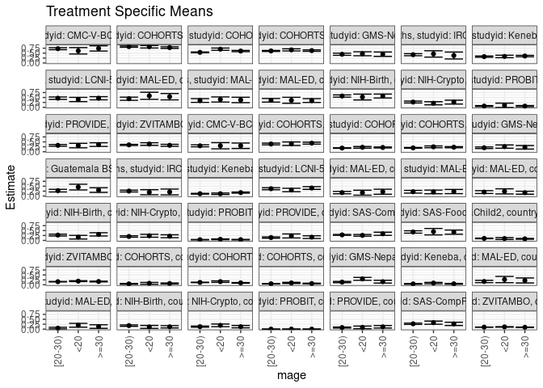

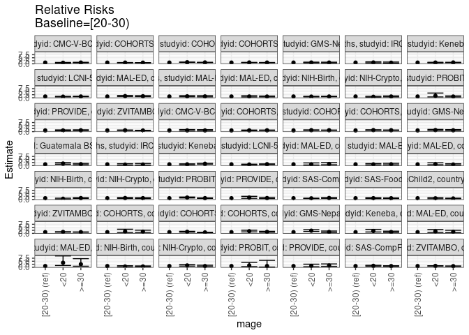

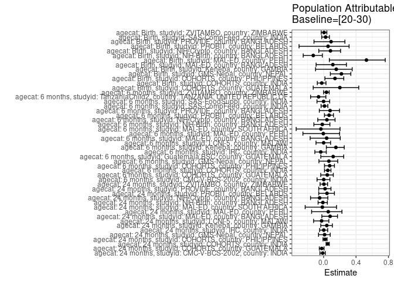

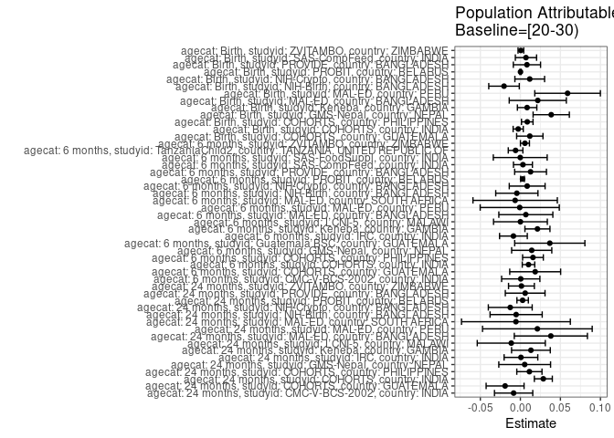

## Results Table

### Parameter: TSM

| agecat | studyid | country | intervention_level | baseline_level | estimate | ci_lower | ci_upper |
| --- | --- | --- | --- | --- | --- | --- | --- |
| Birth | COHORTS | GUATEMALA | [20-30) | NA | 0.0469136 | 0.0263077 | 0.0675195 |
| Birth | COHORTS | GUATEMALA | <20 | NA | 0.0743802 | 0.0276007 | 0.1211596 |
| Birth | COHORTS | GUATEMALA | >=30 | NA | 0.0674847 | 0.0402373 | 0.0947320 |
| Birth | COHORTS | INDIA | [20-30) | NA | 0.1210692 | 0.1097302 | 0.1324082 |
| Birth | COHORTS | INDIA | <20 | NA | 0.1603261 | 0.1228350 | 0.1978171 |
| Birth | COHORTS | INDIA | >=30 | NA | 0.0976864 | 0.0806509 | 0.1147219 |
| Birth | COHORTS | PHILIPPINES | [20-30) | NA | 0.0527183 | 0.0424527 | 0.0629839 |
| Birth | COHORTS | PHILIPPINES | <20 | NA | 0.0952381 | 0.0656412 | 0.1248350 |
| Birth | COHORTS | PHILIPPINES | >=30 | NA | 0.0646298 | 0.0481078 | 0.0811519 |
| Birth | GMS-Nepal | NEPAL | [20-30) | NA | 0.1367713 | 0.1048594 | 0.1686832 |
| Birth | GMS-Nepal | NEPAL | <20 | NA | 0.3020134 | 0.2282393 | 0.3757875 |
| Birth | GMS-Nepal | NEPAL | >=30 | NA | 0.1584158 | 0.0871555 | 0.2296762 |
| Birth | Keneba | GAMBIA | [20-30) | NA | 0.0453901 | 0.0300196 | 0.0607606 |
| Birth | Keneba | GAMBIA | <20 | NA | 0.0882353 | 0.0521888 | 0.1242818 |
| Birth | Keneba | GAMBIA | >=30 | NA | 0.0500000 | 0.0325554 | 0.0674446 |
| Birth | MAL-ED | BANGLADESH | [20-30) | NA | 0.1687500 | 0.1105909 | 0.2269091 |
| Birth | MAL-ED | BANGLADESH | <20 | NA | 0.2666667 | 0.1080808 | 0.4252526 |
| Birth | MAL-ED | BANGLADESH | >=30 | NA | 0.2195122 | 0.0925394 | 0.3464850 |
| Birth | MAL-ED | PERU | [20-30) | NA | 0.0526316 | 0.0115533 | 0.0937099 |
| Birth | MAL-ED | PERU | <20 | NA | 0.1969697 | 0.1008138 | 0.2931256 |
| Birth | MAL-ED | PERU | >=30 | NA | 0.1320755 | 0.0407281 | 0.2234229 |
| Birth | NIH-Birth | BANGLADESH | [20-30) | NA | 0.1804878 | 0.1432301 | 0.2177455 |
| Birth | NIH-Birth | BANGLADESH | <20 | NA | 0.1142857 | 0.0396923 | 0.1888791 |
| Birth | NIH-Birth | BANGLADESH | >=30 | NA | 0.1190476 | 0.0624552 | 0.1756400 |
| Birth | NIH-Crypto | BANGLADESH | [20-30) | NA | 0.1262940 | 0.0966494 | 0.1559386 |
| Birth | NIH-Crypto | BANGLADESH | <20 | NA | 0.1923077 | 0.1245132 | 0.2601022 |
| Birth | NIH-Crypto | BANGLADESH | >=30 | NA | 0.1260504 | 0.0663762 | 0.1857246 |
| Birth | PROBIT | BELARUS | [20-30) | NA | 0.0023132 | 0.0006339 | 0.0039925 |
| Birth | PROBIT | BELARUS | <20 | NA | 0.0035511 | 0.0009338 | 0.0061684 |
| Birth | PROBIT | BELARUS | >=30 | NA | 0.0023603 | -0.0020464 | 0.0067671 |

[output cut: 117 more lines]

### Parameter: E(Y)

| agecat | studyid | country | intervention_level | baseline_level | estimate | ci_lower | ci_upper |
| --- | --- | --- | --- | --- | --- | --- | --- |
| Birth | COHORTS | GUATEMALA | NA | NA | 0.0586854 | 0.0428942 | 0.0744767 |
| Birth | COHORTS | INDIA | NA | NA | 0.1183457 | 0.1091247 | 0.1275667 |
| Birth | COHORTS | PHILIPPINES | NA | NA | 0.0613115 | 0.0527962 | 0.0698268 |
| Birth | GMS-Nepal | NEPAL | NA | NA | 0.1752874 | 0.1470202 | 0.2035545 |
| Birth | Keneba | GAMBIA | NA | NA | 0.0537913 | 0.0425309 | 0.0650518 |
| Birth | MAL-ED | BANGLADESH | NA | NA | 0.1904762 | 0.1397281 | 0.2412242 |
| Birth | MAL-ED | PERU | NA | NA | 0.1115880 | 0.0710726 | 0.1521034 |
| Birth | NIH-Birth | BANGLADESH | NA | NA | 0.1600660 | 0.1308485 | 0.1892835 |
| Birth | NIH-Crypto | BANGLADESH | NA | NA | 0.1379781 | 0.1129774 | 0.1629789 |
| Birth | PROBIT | BELARUS | NA | NA | 0.0024473 | 0.0007336 | 0.0041610 |
| Birth | PROVIDE | BANGLADESH | NA | NA | 0.0890538 | 0.0649864 | 0.1131212 |
| Birth | SAS-CompFeed | INDIA | NA | NA | 0.2787540 | 0.2475949 | 0.3099131 |
| Birth | ZVITAMBO | ZIMBABWE | NA | NA | 0.1032165 | 0.0981467 | 0.1082863 |
| 6 months | CMC-V-BCS-2002 | INDIA | NA | NA | 0.3008130 | 0.2539566 | 0.3476694 |
| 6 months | COHORTS | GUATEMALA | NA | NA | 0.4099896 | 0.3788775 | 0.4411017 |
| 6 months | COHORTS | INDIA | NA | NA | 0.1959625 | 0.1848518 | 0.2070732 |
| 6 months | COHORTS | PHILIPPINES | NA | NA | 0.2112260 | 0.1958496 | 0.2266024 |
| 6 months | GMS-Nepal | NEPAL | NA | NA | 0.2163121 | 0.1823021 | 0.2503220 |
| 6 months | Guatemala BSC | GUATEMALA | NA | NA | 0.3115942 | 0.2568550 | 0.3663334 |
| 6 months | IRC | INDIA | NA | NA | 0.2457002 | 0.2038248 | 0.2875757 |
| 6 months | Keneba | GAMBIA | NA | NA | 0.1408654 | 0.1259115 | 0.1558193 |
| 6 months | LCNI-5 | MALAWI | NA | NA | 0.3736921 | 0.3370052 | 0.4103790 |
| 6 months | MAL-ED | BANGLADESH | NA | NA | 0.1825726 | 0.1336978 | 0.2314474 |
| 6 months | MAL-ED | PERU | NA | NA | 0.2197802 | 0.1705687 | 0.2689917 |
| 6 months | MAL-ED | SOUTH AFRICA | NA | NA | 0.1968504 | 0.1478551 | 0.2458457 |
| 6 months | NIH-Birth | BANGLADESH | NA | NA | 0.2672897 | 0.2297549 | 0.3048246 |
| 6 months | NIH-Crypto | BANGLADESH | NA | NA | 0.2097902 | 0.1799252 | 0.2396552 |
| 6 months | PROBIT | BELARUS | NA | NA | 0.0393401 | 0.0293640 | 0.0493162 |
| 6 months | PROVIDE | BANGLADESH | NA | NA | 0.1589404 | 0.1297581 | 0.1881227 |
| 6 months | SAS-CompFeed | INDIA | NA | NA | 0.2844311 | 0.2666491 | 0.3022132 |
| 6 months | SAS-FoodSuppl | INDIA | NA | NA | 0.4289474 | 0.3791199 | 0.4787748 |
| 6 months | TanzaniaChild2 | TANZANIA, UNITED REPUBLIC OF | NA | NA | 0.0964215 | 0.0835208 | 0.1093221 |
| 6 months | ZVITAMBO | ZIMBABWE | NA | NA | 0.1627181 | 0.1549406 | 0.1704957 |
| 24 months | CMC-V-BCS-2002 | INDIA | NA | NA | 0.7169811 | 0.6710815 | 0.7628807 |
| 24 months | COHORTS | GUATEMALA | NA | NA | 0.8120301 | 0.7885439 | 0.8355162 |
| 24 months | COHORTS | INDIA | NA | NA | 0.5674431 | 0.5514601 | 0.5834261 |
| 24 months | COHORTS | PHILIPPINES | NA | NA | 0.6229039 | 0.6036892 | 0.6421186 |
| 24 months | GMS-Nepal | NEPAL | NA | NA | 0.4487705 | 0.4045970 | 0.4929440 |
| 24 months | IRC | INDIA | NA | NA | 0.4205379 | 0.3726382 | 0.4684376 |
| 24 months | Keneba | GAMBIA | NA | NA | 0.3372229 | 0.3148351 | 0.3596107 |
| 24 months | LCNI-5 | MALAWI | NA | NA | 0.4526316 | 0.4078220 | 0.4974412 |
| 24 months | MAL-ED | BANGLADESH | NA | NA | 0.4764151 | 0.4090254 | 0.5438047 |
| 24 months | MAL-ED | PERU | NA | NA | 0.3681592 | 0.3013164 | 0.4350020 |
| 24 months | MAL-ED | SOUTH AFRICA | NA | NA | 0.3529412 | 0.2921001 | 0.4137823 |
| 24 months | NIH-Birth | BANGLADESH | NA | NA | 0.5690867 | 0.5220618 | 0.6161115 |
| 24 months | NIH-Crypto | BANGLADESH | NA | NA | 0.2568093 | 0.2190047 | 0.2946140 |
| 24 months | PROBIT | BELARUS | NA | NA | 0.0681537 | 0.0420376 | 0.0942697 |
| 24 months | PROVIDE | BANGLADESH | NA | NA | 0.3287197 | 0.2903909 | 0.3670485 |
| 24 months | ZVITAMBO | ZIMBABWE | NA | NA | 0.3473748 | 0.3243098 | 0.3704399 |

### Parameter: RR

| agecat | studyid | country | intervention_level | baseline_level | estimate | ci_lower | ci_upper |
| --- | --- | --- | --- | --- | --- | --- | --- |
| Birth | COHORTS | GUATEMALA | [20-30) | [20-30) | 1.0000000 | 1.0000000 | 1.0000000 |
| Birth | COHORTS | GUATEMALA | <20 | [20-30) | 1.5854719 | 0.7362135 | 3.4143916 |
| Birth | COHORTS | GUATEMALA | >=30 | [20-30) | 1.4384889 | 0.7921406 | 2.6122258 |
| Birth | COHORTS | INDIA | [20-30) | [20-30) | 1.0000000 | 1.0000000 | 1.0000000 |
| Birth | COHORTS | INDIA | <20 | [20-30) | 1.3242518 | 1.0293699 | 1.7036081 |
| Birth | COHORTS | INDIA | >=30 | [20-30) | 0.8068641 | 0.6619614 | 0.9834858 |
| Birth | COHORTS | PHILIPPINES | [20-30) | [20-30) | 1.0000000 | 1.0000000 | 1.0000000 |
| Birth | COHORTS | PHILIPPINES | <20 | [20-30) | 1.8065476 | 1.2519257 | 2.6068754 |
| Birth | COHORTS | PHILIPPINES | >=30 | [20-30) | 1.2259474 | 0.8890135 | 1.6905784 |
| Birth | GMS-Nepal | NEPAL | [20-30) | [20-30) | 1.0000000 | 1.0000000 | 1.0000000 |
| Birth | GMS-Nepal | NEPAL | <20 | [20-30) | 2.2081637 | 1.5751650 | 3.0955405 |
| Birth | GMS-Nepal | NEPAL | >=30 | [20-30) | 1.1582535 | 0.6977958 | 1.9225555 |
| Birth | Keneba | GAMBIA | [20-30) | [20-30) | 1.0000000 | 1.0000000 | 1.0000000 |
| Birth | Keneba | GAMBIA | <20 | [20-30) | 1.9439338 | 1.1434917 | 3.3046840 |
| Birth | Keneba | GAMBIA | >=30 | [20-30) | 1.1015625 | 0.6774116 | 1.7912890 |
| Birth | MAL-ED | BANGLADESH | [20-30) | [20-30) | 1.0000000 | 1.0000000 | 1.0000000 |
| Birth | MAL-ED | BANGLADESH | <20 | [20-30) | 1.5802469 | 0.7947195 | 3.1422159 |
| Birth | MAL-ED | BANGLADESH | >=30 | [20-30) | 1.3008130 | 0.6634287 | 2.5505598 |
| Birth | MAL-ED | PERU | [20-30) | [20-30) | 1.0000000 | 1.0000000 | 1.0000000 |
| Birth | MAL-ED | PERU | <20 | [20-30) | 3.7424242 | 1.4905555 | 9.3963221 |
| Birth | MAL-ED | PERU | >=30 | [20-30) | 2.5094340 | 0.8844567 | 7.1199176 |
| Birth | NIH-Birth | BANGLADESH | [20-30) | [20-30) | 1.0000000 | 1.0000000 | 1.0000000 |
| Birth | NIH-Birth | BANGLADESH | <20 | [20-30) | 0.6332046 | 0.3193333 | 1.2555786 |
| Birth | NIH-Birth | BANGLADESH | >=30 | [20-30) | 0.6595882 | 0.3928211 | 1.1075183 |
| Birth | NIH-Crypto | BANGLADESH | [20-30) | [20-30) | 1.0000000 | 1.0000000 | 1.0000000 |
| Birth | NIH-Crypto | BANGLADESH | <20 | [20-30) | 1.5226986 | 0.9969618 | 2.3256770 |
| Birth | NIH-Crypto | BANGLADESH | >=30 | [20-30) | 0.9980714 | 0.5884036 | 1.6929646 |
| Birth | PROBIT | BELARUS | [20-30) | [20-30) | 1.0000000 | 1.0000000 | 1.0000000 |
| Birth | PROBIT | BELARUS | <20 | [20-30) | 1.5351716 | 0.5837072 | 4.0375581 |
| Birth | PROBIT | BELARUS | >=30 | [20-30) | 1.0203879 | 0.1810456 | 5.7509893 |

[output cut: 117 more lines]

### Parameter: PAR

| agecat | studyid | country | intervention_level | baseline_level | estimate | ci_lower | ci_upper |
| --- | --- | --- | --- | --- | --- | --- | --- |
| Birth | COHORTS | GUATEMALA | [20-30) | NA | 0.0117719 | -0.0046688 | 0.0282125 |
| Birth | COHORTS | INDIA | [20-30) | NA | -0.0027235 | -0.0090614 | 0.0036145 |
| Birth | COHORTS | PHILIPPINES | [20-30) | NA | 0.0085932 | 0.0013782 | 0.0158082 |
| Birth | GMS-Nepal | NEPAL | [20-30) | NA | 0.0385161 | 0.0158831 | 0.0611490 |
| Birth | Keneba | GAMBIA | [20-30) | NA | 0.0084012 | -0.0037298 | 0.0205323 |
| Birth | MAL-ED | BANGLADESH | [20-30) | NA | 0.0217262 | -0.0139411 | 0.0573935 |
| Birth | MAL-ED | PERU | [20-30) | NA | 0.0589564 | 0.0179966 | 0.0999162 |
| Birth | NIH-Birth | BANGLADESH | [20-30) | NA | -0.0204218 | -0.0394864 | -0.0013572 |
| Birth | NIH-Crypto | BANGLADESH | [20-30) | NA | 0.0116841 | -0.0068661 | 0.0302344 |
| Birth | PROBIT | BELARUS | [20-30) | NA | 0.0001341 | -0.0006282 | 0.0008964 |
| Birth | PROVIDE | BANGLADESH | [20-30) | NA | 0.0081913 | -0.0088047 | 0.0251872 |
| Birth | SAS-CompFeed | INDIA | [20-30) | NA | 0.0069806 | -0.0062865 | 0.0202478 |
| Birth | ZVITAMBO | ZIMBABWE | [20-30) | NA | 0.0006248 | -0.0029260 | 0.0041756 |
| 6 months | CMC-V-BCS-2002 | INDIA | [20-30) | NA | 0.0004717 | -0.0234227 | 0.0243661 |
| 6 months | COHORTS | GUATEMALA | [20-30) | NA | 0.0185002 | -0.0132890 | 0.0502894 |
| 6 months | COHORTS | INDIA | [20-30) | NA | 0.0101324 | 0.0023295 | 0.0179353 |
| 6 months | COHORTS | PHILIPPINES | [20-30) | NA | 0.0157232 | 0.0027785 | 0.0286678 |
| 6 months | GMS-Nepal | NEPAL | [20-30) | NA | 0.0141557 | -0.0109176 | 0.0392290 |
| 6 months | Guatemala BSC | GUATEMALA | [20-30) | NA | 0.0367404 | -0.0070980 | 0.0805788 |
| 6 months | IRC | INDIA | [20-30) | NA | -0.0086857 | -0.0260063 | 0.0086349 |
| 6 months | Keneba | GAMBIA | [20-30) | NA | 0.0213112 | 0.0056745 | 0.0369479 |
| 6 months | LCNI-5 | MALAWI | [20-30) | NA | 0.0000657 | -0.0335168 | 0.0336482 |
| 6 months | MAL-ED | BANGLADESH | [20-30) | NA | 0.0068150 | -0.0269196 | 0.0405497 |
| 6 months | MAL-ED | PERU | [20-30) | NA | -0.0008080 | -0.0502006 | 0.0485845 |
| 6 months | MAL-ED | SOUTH AFRICA | [20-30) | NA | -0.0065394 | -0.0592253 | 0.0461465 |
| 6 months | NIH-Birth | BANGLADESH | [20-30) | NA | -0.0044190 | -0.0307839 | 0.0219460 |
| 6 months | NIH-Crypto | BANGLADESH | [20-30) | NA | 0.0084915 | -0.0138827 | 0.0308657 |
| 6 months | PROBIT | BELARUS | [20-30) | NA | 0.0026664 | 0.0003246 | 0.0050082 |
| 6 months | PROVIDE | BANGLADESH | [20-30) | NA | 0.0127140 | -0.0071334 | 0.0325614 |
| 6 months | SAS-CompFeed | INDIA | [20-30) | NA | 0.0032119 | -0.0086234 | 0.0150472 |
| 6 months | SAS-FoodSuppl | INDIA | [20-30) | NA | -0.0001714 | -0.0338145 | 0.0334717 |
| 6 months | TanzaniaChild2 | TANZANIA, UNITED REPUBLIC OF | [20-30) | NA | -0.0060064 | -0.0151323 | 0.0031194 |
| 6 months | ZVITAMBO | ZIMBABWE | [20-30) | NA | 0.0056948 | 0.0000755 | 0.0113141 |
| 24 months | CMC-V-BCS-2002 | INDIA | [20-30) | NA | -0.0084426 | -0.0323497 | 0.0154645 |
| 24 months | COHORTS | GUATEMALA | [20-30) | NA | -0.0190895 | -0.0427796 | 0.0046007 |
| 24 months | COHORTS | INDIA | [20-30) | NA | 0.0286693 | 0.0174496 | 0.0398890 |
| 24 months | COHORTS | PHILIPPINES | [20-30) | NA | 0.0112600 | -0.0044796 | 0.0269997 |
| 24 months | GMS-Nepal | NEPAL | [20-30) | NA | 0.0053743 | -0.0269564 | 0.0377050 |
| 24 months | IRC | INDIA | [20-30) | NA | 0.0007128 | -0.0203193 | 0.0217449 |
| 24 months | Keneba | GAMBIA | [20-30) | NA | 0.0131722 | -0.0110049 | 0.0373494 |
| 24 months | LCNI-5 | MALAWI | [20-30) | NA | -0.0113684 | -0.0538695 | 0.0311327 |
| 24 months | MAL-ED | BANGLADESH | [20-30) | NA | 0.0380589 | -0.0076062 | 0.0837241 |
| 24 months | MAL-ED | PERU | [20-30) | NA | 0.0212204 | -0.0472631 | 0.0897040 |
| 24 months | MAL-ED | SOUTH AFRICA | [20-30) | NA | -0.0055494 | -0.0734902 | 0.0623914 |
| 24 months | NIH-Birth | BANGLADESH | [20-30) | NA | -0.0053078 | -0.0378581 | 0.0272425 |
| 24 months | NIH-Crypto | BANGLADESH | [20-30) | NA | -0.0126517 | -0.0400293 | 0.0147258 |
| 24 months | PROBIT | BELARUS | [20-30) | NA | 0.0028235 | -0.0043175 | 0.0099646 |
| 24 months | PROVIDE | BANGLADESH | [20-30) | NA | 0.0059813 | -0.0188215 | 0.0307841 |
| 24 months | ZVITAMBO | ZIMBABWE | [20-30) | NA | 0.0013258 | -0.0147976 | 0.0174492 |

### Parameter: PAF

| agecat | studyid | country | intervention_level | baseline_level | estimate | ci_lower | ci_upper |
| --- | --- | --- | --- | --- | --- | --- | --- |
| Birth | COHORTS | GUATEMALA | [20-30) | NA | 0.2005926 | -0.1282348 | 0.4335823 |
| Birth | COHORTS | INDIA | [20-30) | NA | -0.0230129 | -0.0779712 | 0.0291434 |
| Birth | COHORTS | PHILIPPINES | [20-30) | NA | 0.1401563 | 0.0156931 | 0.2488814 |
| Birth | GMS-Nepal | NEPAL | [20-30) | NA | 0.2197309 | 0.0831896 | 0.3359371 |
| Birth | Keneba | GAMBIA | [20-30) | NA | 0.1561822 | -0.0995395 | 0.3524302 |
| Birth | MAL-ED | BANGLADESH | [20-30) | NA | 0.1140625 | -0.0926693 | 0.2816809 |
| Birth | MAL-ED | PERU | [20-30) | NA | 0.5283401 | 0.0707564 | 0.7605977 |
| Birth | NIH-Birth | BANGLADESH | [20-30) | NA | -0.1275836 | -0.2517561 | -0.0157288 |
| Birth | NIH-Crypto | BANGLADESH | [20-30) | NA | 0.0846811 | -0.0594190 | 0.2091811 |
| Birth | PROBIT | BELARUS | [20-30) | NA | 0.0547917 | -0.3031102 | 0.3143951 |
| Birth | PROVIDE | BANGLADESH | [20-30) | NA | 0.0919811 | -0.1187609 | 0.2630255 |
| Birth | SAS-CompFeed | INDIA | [20-30) | NA | 0.0250423 | -0.0236488 | 0.0714174 |
| Birth | ZVITAMBO | ZIMBABWE | [20-30) | NA | 0.0060533 | -0.0289497 | 0.0398656 |
| 6 months | CMC-V-BCS-2002 | INDIA | [20-30) | NA | 0.0015681 | -0.0811098 | 0.0779232 |
| 6 months | COHORTS | GUATEMALA | [20-30) | NA | 0.0451237 | -0.0356747 | 0.1196185 |
| 6 months | COHORTS | INDIA | [20-30) | NA | 0.0517058 | 0.0111000 | 0.0906443 |
| 6 months | COHORTS | PHILIPPINES | [20-30) | NA | 0.0744377 | 0.0112091 | 0.1336232 |
| 6 months | GMS-Nepal | NEPAL | [20-30) | NA | 0.0654412 | -0.0577158 | 0.1742582 |
| 6 months | Guatemala BSC | GUATEMALA | [20-30) | NA | 0.1179111 | -0.0342598 | 0.2476930 |
| 6 months | IRC | INDIA | [20-30) | NA | -0.0353509 | -0.1082112 | 0.0327192 |
| 6 months | Keneba | GAMBIA | [20-30) | NA | 0.1512876 | 0.0336555 | 0.2546004 |
| 6 months | LCNI-5 | MALAWI | [20-30) | NA | 0.0001758 | -0.0938534 | 0.0861222 |
| 6 months | MAL-ED | BANGLADESH | [20-30) | NA | 0.0373278 | -0.1661830 | 0.2053239 |
| 6 months | MAL-ED | PERU | [20-30) | NA | -0.0036765 | -0.2555603 | 0.1976758 |
| 6 months | MAL-ED | SOUTH AFRICA | [20-30) | NA | -0.0332203 | -0.3386458 | 0.2025192 |
| 6 months | NIH-Birth | BANGLADESH | [20-30) | NA | -0.0165325 | -0.1201071 | 0.0774648 |
| 6 months | NIH-Crypto | BANGLADESH | [20-30) | NA | 0.0404762 | -0.0722415 | 0.1413446 |
| 6 months | PROBIT | BELARUS | [20-30) | NA | 0.0677773 | 0.0108308 | 0.1214453 |
| 6 months | PROVIDE | BANGLADESH | [20-30) | NA | 0.0799921 | -0.0531057 | 0.1962683 |
| 6 months | SAS-CompFeed | INDIA | [20-30) | NA | 0.0112922 | -0.0313819 | 0.0522007 |
| 6 months | SAS-FoodSuppl | INDIA | [20-30) | NA | -0.0003996 | -0.0819879 | 0.0750364 |
| 6 months | TanzaniaChild2 | TANZANIA, UNITED REPUBLIC OF | [20-30) | NA | -0.0622937 | -0.1609727 | 0.0279979 |
| 6 months | ZVITAMBO | ZIMBABWE | [20-30) | NA | 0.0349978 | -0.0001352 | 0.0688966 |
| 24 months | CMC-V-BCS-2002 | INDIA | [20-30) | NA | -0.0117752 | -0.0457112 | 0.0210595 |
| 24 months | COHORTS | GUATEMALA | [20-30) | NA | -0.0235083 | -0.0531660 | 0.0053141 |
| 24 months | COHORTS | INDIA | [20-30) | NA | 0.0505236 | 0.0304661 | 0.0701661 |
| 24 months | COHORTS | PHILIPPINES | [20-30) | NA | 0.0180767 | -0.0075336 | 0.0430360 |
| 24 months | GMS-Nepal | NEPAL | [20-30) | NA | 0.0119755 | -0.0627652 | 0.0814600 |
| 24 months | IRC | INDIA | [20-30) | NA | 0.0016950 | -0.0495915 | 0.0504755 |
| 24 months | Keneba | GAMBIA | [20-30) | NA | 0.0390609 | -0.0353750 | 0.1081455 |
| 24 months | LCNI-5 | MALAWI | [20-30) | NA | -0.0251163 | -0.1234739 | 0.0646303 |
| 24 months | MAL-ED | BANGLADESH | [20-30) | NA | 0.0798861 | -0.0216336 | 0.1713177 |
| 24 months | MAL-ED | PERU | [20-30) | NA | 0.0576393 | -0.1480413 | 0.2264706 |
| 24 months | MAL-ED | SOUTH AFRICA | [20-30) | NA | -0.0157233 | -0.2276749 | 0.1596360 |
| 24 months | NIH-Birth | BANGLADESH | [20-30) | NA | -0.0093269 | -0.0681852 | 0.0462882 |
| 24 months | NIH-Crypto | BANGLADESH | [20-30) | NA | -0.0492651 | -0.1614003 | 0.0520432 |
| 24 months | PROBIT | BELARUS | [20-30) | NA | 0.0414292 | -0.0603184 | 0.1334130 |
| 24 months | PROVIDE | BANGLADESH | [20-30) | NA | 0.0181959 | -0.0602307 | 0.0908211 |
| 24 months | ZVITAMBO | ZIMBABWE | [20-30) | NA | 0.0038166 | -0.0436967 | 0.0491670 |